# Methodology

**Tools**

For disk bandwidth test, we use Fio. Fio is short for Flexible IO, a versatile IO workload generator. It was written to benchmark or verify changes to the Linux IO subsystem by Linux developers. Fio is flexible enough to allow detailed workload setups, and it contains the necessary reporting to make sense of the data at completion. Fio is widely used as an industry standard benchmark, stress testing tool, and for IO verification purposes. Fio isn't tied to any OS. It works on any platform from Windows to HP-UX to Android. There are also native IO engines on Linux, Windows, Solaris, etc. This is a key feature to make the measurement repeatable across platforms.

Fio also supports three different types of output formats. The “classic” output is the default which dumps workload statistics at the end of the workload. There's also support for a CSV format called Terse, though that's slowly diminishing in favor of a JSON-based output format. The latter is far more flexible and has the advantage of being simple to parse for people and computers. However, JSON format only available in later version of FIO. We prefer the terse format since it's available to more versions of FIO. Especially, it is an advantage on some of the hosts where users are not able to upgrade FIO version.

**Test Design**

During our measurement, we saw that the bandwidth of random read/write and sequential read/write is very different. To keep the same setting for the test and control the time for each test, we have to consider carefully the size of transfered data, number of parallel threads, number of VMs on one host. If the size is too small, the job finish too quickly, we cannot see the a stable bandwidth of sequential read/write. If the data volume is too big, the random read/write test is take too long to finish. The number of parallel threads also affect a lot on the bandwith (as explained in the result assessment section). We run same number of Virtual Machines. We run Fio on the physical host with different number of Fio threads (from 1 to 16 concurrent threads). Then with the same configuration, we run it from inside different flavors of VM. We also make the comparison with the case that each VM has only one thread but we use many concurrent active VMs on the same host to perform I/O operation. We use identical Operating Systems and identical OS' setting across platforms to make sure that the measurement result is reliable.

Our configuration file for Fio has this structure:

```
; sample setting of one thread
[sequential-read]
rw=read
size=(4gb/number_of_parallel_threads)
directory=/home/cloud-user/fiodata
ioengine=libaio
direct=1
iodepth=16
```

Where:

- *rw* defines the kind of disk access pattern: read (sequential reads), write (sequential writes), randread (random reads), randwrite (random writes), or mixed. We specially focus on these only 2 basic access patterns which was happen mostly in the context Big Data world: Sequential read and sequential write. A typical example is the Hadoop File System (HDFS) which has only sequential read and sequential write.
- *size* is the total size of file io for this job. Fio will run until this many bytes of data has been transferred. We choose the total transfer volume to be 4 GBs. This is large enough to avoid many kinds of buffering from the application layet to the OS layer and then to the hardware layer. In facts, some of our initary tests have show that the smaller of size of data volume can cause some very ridiculous results. For example, on some tests we have repoted aggregated throughput of 300MB/s on a single "Seagate Constellation.2 1TB" hard drive while one of professional harddrive benchmarking website claims that the maximum achivable throughput is just about 115 MB/s (http://www.storagereview.com/seagate_constellation2_and_constellation_es2_hard_drive_review). And this is value is more convincing than the 300MB/s one. The data will be divided to threads equally between parallel threads:
  - 1 thread: transfers entire 4 GBs
  - 2 threads: each thread transfer 2 GBs
  - 4 threads: each thread transfer 1 GBs
  - 8 threads: each thread transfer 512 MBs
  - 16 threads: each thread transfer 256 MBs
- *direct I/O* set the value of O_DIRECT in the Linux kernel. I/O operations performed against files opened with O_DIRECT bypass the kernel's page cache, writing directly to the storage. Recall that the storage may itself store the data in a write-back cache (in our case, the storage has 64 MBs of write-back cache). There is no strict guarantee that the function will return only after all data has been transferred.
- *iodepth* defines the I/O depth of the system. This defines how many io units to keep in flight against the file. The default is 1 for each file defined in the job discription. This value can be overridden with a larger value for higher concurrency. We use I/O depth of 16. In fact, the default I/O depth in some of the Linux distribution can even be set upto 256 or 512.
- *ioengine* is libaio which indicates the application to use AIO subsystem. AIO (Asynchronous Linux IO) help to overlaps processing with I/O Operations. Application can submit (batch) IO without waiting for completion. This benefits physical IO in particular when prefetching data. Besides, It allows to accumulate read or write requests so that the IO subsystem can optimize performance by grouping or reordering the IO request in favor of sequential access and large request. It helps to separate calls for submission and completion indication and pipelines operations to improve throughput. It also helps to improved utilization of CPU and devices.

# Result assessment

Import library to use

```python
# Set figure to display inside notebook
%matplotlib inline
####
import numpy as np
from pandas import *
import pandas as pd
import matplotlib.pyplot as plt
from matplotlib import *
import matplotlib.pylab as pylab
import scipy.stats as td
```

Reading input to pandas

```python
dtresult = pd.read_csv('data/bw16p4g_bf7.csv', delimiter=' ', header=None)
dtdata = dtresult[range(1,17)]
dtindex = dtresult[0]
dtdata.index = dtindex.str.replace('T[0-2][0-9]', '',case=False)
```

```python
# To calculate the average throughput, we first calculate average throughput each thread has in one test, then again take the
# average of 5 tests
avgtpin1test = dtdata.T.mean() # Average throughput of each thread/VM in one test
avgtpin5tests = avgtpin1test.groupby(level=0).mean() # Average throughput of each thread/VM in 5 tests
avgtpin5tests = avgtpin5tests / 1024 # Converting to Megabytes/second
```

```python
# Putting average throughput per thread/VM to vector before plotting
bwsrbf = avgtpin5tests.filter(regex="^SRBFTH").tolist()
bwswbf = avgtpin5tests.filter(regex="^SWBFTH").tolist()

bwsrsvm1c = avgtpin5tests.filter(regex="^SR01VM01CTH").tolist()
bwswsvm1c = avgtpin5tests.filter(regex="^SW01VM01CTH").tolist()
bwsrsvm2c = avgtpin5tests.filter(regex="^SR01VM02CTH").tolist()
bwswsvm2c = avgtpin5tests.filter(regex="^SW01VM02CTH").tolist()
bwsrsvm4c = avgtpin5tests.filter(regex="^SR01VM04CTH").tolist()
bwswsvm4c = avgtpin5tests.filter(regex="^SW01VM04CTH").tolist()
bwsrsvm8c = avgtpin5tests.filter(regex="^SR[0-9]+VM01CTH01").tolist()
bwswsvm8c = avgtpin5tests.filter(regex="^SW01VM08CTH").tolist()
bwsrsvm16c = avgtpin5tests.filter(regex="^SR01VM16CTH").tolist()
bwswsvm16c = avgtpin5tests.filter(regex="^SW01VM16CTH").tolist()

bwsrmvm = avgtpin5tests.filter(regex="^SR[0-9]+VM01CTH01").tolist()
bwswmvm = avgtpin5tests.filter(regex="^SW[0-9]+VM01CTH01").tolist()
```

```python
# Calculate aggregated throughput on each host of each test, then taking the average
aggtpin1test = dtdata.T.sum() # Aggregate throughput on each host in one test
avgaggtpintestgrouped = aggtpin1test.groupby(level=0)
avgaggtpin5tests = avgaggtpintestgrouped.mean() # Then calculate the average of the total throughput through 5 tests
avgaggtpin5tests = avgaggtpin5tests / 1024 # Convert to MB/s
ciaggtpin5tests = avgaggtpintestgrouped.aggregate(lambda x: np.std(x) / np.sqrt(x.count()) * 1.96) # Confident interval of 95%
ciaggtpin5tests = ciaggtpin5tests / 1024 # Convert to same scale with mean
```

```python
# Putting average aggregate throughput to vector before plotting
aggbwsrbf = avgaggtpin5tests.filter(regex="^SRBFTH").tolist()
aggbwswbf = avgaggtpin5tests.filter(regex="^SWBFTH").tolist()
aggbwsrsvm1c = avgaggtpin5tests.filter(regex="^SR01VM01CTH").tolist()
aggbwswsvm1c = avgaggtpin5tests.filter(regex="^SW01VM01CTH").tolist()
aggbwsrsvm2c = avgaggtpin5tests.filter(regex="^SR01VM02CTH").tolist()
aggbwswsvm2c = avgaggtpin5tests.filter(regex="^SW01VM02CTH").tolist()
aggbwsrsvm4c = avgaggtpin5tests.filter(regex="^SR01VM04CTH").tolist()
aggbwswsvm4c = avgaggtpin5tests.filter(regex="^SW01VM04CTH").tolist()
aggbwsrsvm8c = avgaggtpin5tests.filter(regex="^SR01VM08CTH").tolist()
aggbwswsvm8c = avgaggtpin5tests.filter(regex="^SW01VM08CTH").tolist()
aggbwsrsvm16c = avgaggtpin5tests.filter(regex="^SR01VM16CTH").tolist()
aggbwswsvm16c = avgaggtpin5tests.filter(regex="^SW01VM16CTH").tolist()
aggbwsrmvm = avgaggtpin5tests.filter(regex="^SR[0-9]+VM01CTH01").tolist()
aggbwswmvm = avgaggtpin5tests.filter(regex="^SW[0-9]+VM01CTH01").tolist()

# Confidence Interval
ciaggbwsrbf = ciaggtpin5tests.filter(regex="^SRBFTH").tolist()
ciaggbwswbf = ciaggtpin5tests.filter(regex="^SWBFTH").tolist()
ciaggbwsrsvm1c = ciaggtpin5tests.filter(regex="^SR01VM01CTH").tolist()
ciaggbwswsvm1c = ciaggtpin5tests.filter(regex="^SW01VM01CTH").tolist()
ciaggbwsrsvm2c = ciaggtpin5tests.filter(regex="^SR01VM02CTH").tolist()
ciaggbwswsvm2c = ciaggtpin5tests.filter(regex="^SW01VM02CTH").tolist()
ciaggbwsrsvm4c = ciaggtpin5tests.filter(regex="^SR01VM04CTH").tolist()
ciaggbwswsvm4c = ciaggtpin5tests.filter(regex="^SW01VM04CTH").tolist()
ciaggbwsrsvm8c = ciaggtpin5tests.filter(regex="^SR01VM08CTH").tolist()
ciaggbwswsvm8c = ciaggtpin5tests.filter(regex="^SW01VM08CTH").tolist()
ciaggbwsrsvm16c = ciaggtpin5tests.filter(regex="^SR01VM16CTH").tolist()
ciaggbwswsvm16c = ciaggtpin5tests.filter(regex="^SW01VM16CTH").tolist()
ciaggbwsrmvm = ciaggtpin5tests.filter(regex="^SR[0-9]+VM01CTH01").tolist()
ciaggbwswmvm = ciaggtpin5tests.filter(regex="^SW[0-9]+VM01CTH01").tolist()

# Number of processes = number of core
aggbwsrsvm = [aggbwsrsvm1c[0], aggbwsrsvm2c[1], aggbwsrsvm4c[2], aggbwsrsvm8c[3], aggbwsrsvm16c[4]]
aggbwswsvm = [aggbwswsvm1c[0], aggbwswsvm2c[1], aggbwswsvm4c[2], aggbwswsvm8c[3], aggbwswsvm16c[4]]
ciaggbwsrsvm = [ciaggbwsrsvm1c[0], ciaggbwsrsvm2c[1], ciaggbwsrsvm4c[2], ciaggbwsrsvm8c[3], ciaggbwsrsvm16c[4]]
ciaggbwswsvm = [ciaggbwswsvm1c[0], ciaggbwswsvm2c[1], ciaggbwswsvm4c[2], ciaggbwswsvm8c[3], ciaggbwswsvm16c[4]]
```

## Throughput

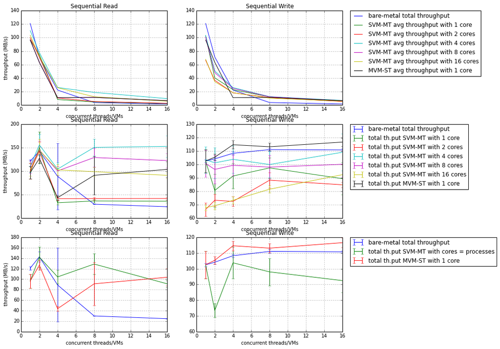

```python
x_axis = [1,2,4,8,16]
pylab.rcParams['figure.figsize'] = 12, 12  # change default size of figures
plt.subplot(321)
plt.plot(x_axis, bwsrbf)
plt.plot(x_axis, bwsrsvm1c)
plt.plot(x_axis, bwsrsvm2c)
plt.plot(x_axis, bwsrsvm4c)
plt.plot(x_axis, bwsrsvm8c)
plt.plot(x_axis, bwsrsvm16c)
plt.plot(x_axis, bwsrmvm)
#plt.axis([0.9, 16.1, 0, 150])
plt.grid(True)
plt.title('Sequential Read')
pylab.xlabel('concurrent threads/VMs')
pylab.ylabel('throughput (MB/s)')

plt.subplot(322)
plt.plot(x_axis, bwsrbf, label = 'bare-metal total throughput')
plt.plot(x_axis, bwswsvm1c, label = 'SVM-MT avg throughput with 1 core')
plt.plot(x_axis, bwswsvm2c, label = 'SVM-MT avg throughput with 2 cores')
plt.plot(x_axis, bwswsvm4c, label = 'SVM-MT avg throughput with 4 cores')
plt.plot(x_axis, bwswsvm8c, label = 'SVM-MT avg throughput with 8 cores')
plt.plot(x_axis, bwswsvm16c, label = 'SVM-MT avg throughput with 16 cores')
plt.plot(x_axis, bwsrmvm, label = 'MVM-ST avg throughput with 1 core')
#plt.axis([0.9, 16.1, 0, 150])
plt.grid(True)
plt.legend(bbox_to_anchor=(1.05, 1), loc=2, borderaxespad=0.)
plt.title('Sequential Write')
pylab.xlabel('concurrent threads/VMs')
#pylab.ylabel('throughput (MB/s)')

plt.subplot(323)
plt.errorbar(x_axis, aggbwsrbf, ciaggbwsrbf)
plt.errorbar(x_axis, aggbwsrsvm1c, ciaggbwsrsvm1c)
plt.errorbar(x_axis, aggbwsrsvm2c, ciaggbwsrsvm2c)
plt.errorbar(x_axis, aggbwsrsvm4c, ciaggbwsrsvm4c)
plt.errorbar(x_axis, aggbwsrsvm8c, ciaggbwsrsvm8c)
plt.errorbar(x_axis, aggbwsrsvm16c, ciaggbwsrsvm16c)
plt.errorbar(x_axis, aggbwsrmvm, ciaggbwsrmvm)
#plt.axis([0.9, 16.1, 0, 150])
plt.grid(True)
plt.title('Sequential Read')
pylab.xlabel('concurrent threads/VMs')
pylab.ylabel('throughput (MB/s)')

plt.subplot(324)
plt.errorbar(x_axis, aggbwswbf, ciaggbwswbf, label = 'bare-metal total throughput')
plt.errorbar(x_axis, aggbwswsvm1c, ciaggbwswsvm1c, label = 'total th.put SVM-MT with 1 core')
plt.errorbar(x_axis, aggbwswsvm2c, ciaggbwswsvm2c, label = 'total th.put SVM-MT with 2 cores')
plt.errorbar(x_axis, aggbwswsvm4c, ciaggbwswsvm4c, label = 'total th.put SVM-MT with 4 cores')
plt.errorbar(x_axis, aggbwswsvm8c, ciaggbwswsvm8c, label = 'total th.put SVM-MT with 8 cores')
plt.errorbar(x_axis, aggbwswsvm16c, ciaggbwswsvm16c, label = 'total th.put SVM-MT with 16 cores')
plt.errorbar(x_axis, aggbwswmvm, ciaggbwswmvm, label = 'total th.put MVM-ST with 1 core')
#plt.axis([0.9, 16.1, 0, 150])
plt.grid(True)
plt.title('Sequential Write')
plt.legend(bbox_to_anchor=(1.05, 1), loc=2, borderaxespad=0.)
pylab.xlabel('concurrent threads/VMs')
#pylab.ylabel('throughput (MB/s)')

plt.subplot(325)
plt.errorbar(x_axis, aggbwsrbf, ciaggbwsrbf)
plt.errorbar(x_axis, aggbwsrsvm, ciaggbwsrsvm)
plt.errorbar(x_axis, aggbwsrmvm, ciaggbwsrmvm)
#plt.axis([0.9, 16.1, 0, 150])
plt.grid(True)
plt.title('Sequential Read')
pylab.xlabel('concurrent threads/VMs')
pylab.ylabel('throughput (MB/s)')

plt.subplot(326)
plt.errorbar(x_axis, aggbwswbf, ciaggbwswbf, label = 'bare-metal total throughput')
plt.errorbar(x_axis, aggbwswsvm, ciaggbwswsvm, label = 'total th.put SVM-MT with cores = processes')
plt.errorbar(x_axis, aggbwswmvm, ciaggbwswmvm, label = 'total th.put MVM-ST with 1 core')
#plt.axis([0.9, 16.1, 0, 150])
plt.grid(True)
plt.title('Sequential Write')
plt.legend(bbox_to_anchor=(1.05, 1), loc=2, borderaxespad=0.)
pylab.xlabel('concurrent threads/VMs')

#plt.savefig('throughput16procs.pdf')
```

The two top figures represent the average throughput of each thread in the test, while the bottom ones represent the aggregated throughput from all threads/VMs in the same scenario. With the three scenarios, we have very different behavior. Let me remind you about the three scenarios that we have:

- Bare metal (BM): we have multiple threads concurrently reading data from or writing data to the disk. All the data was read from or written to a directory placed on the same hard drive.
- Single VM with multiple threads (SVM-MT): in this scenario, we have selected 5 different VM flavors (5 different VM's specs). For each of the flavor, we ran the same test with the involvement of 1 to 16 threads. We plotted the performance of each flavor in a distinct line.
- Multiple VMs with a single threads (MVM-ST): in this scenario, we have from 1 to 16 VMs, each VM initiates only one process to read/write data.

The same fixed amount of data was used throughout the test. When there is many concurrent threads or concurrent VMs running in one test, we distributed the data equally to all of them.

The most unexpected point is on the plot of MVM-ST. We see that its behavior is very strange and provide some possibilities that may happens inside:

1) We used ssh to start the threads inside each VM in parallel. Due to the handshake of ssh-server and ssh-client at the beginning of the test, our processes may not start at the same time, so the aggregated throughput in this scenario is not the aggregated throughput of parallel process from different VMs but rather the aggregated throughput of mixed serial and parallel processes. To fixed, we write a program to listen on port 3000 of all nodes joining the test. On the control machine, we use a client program to send only the "start" command to all nodes through TCP protocol. But the result is not so different with the previous one. That is why we came to another explanation.

[figure not shown]

2) By observing the bandwidth detail of each node in each test, We saw that there are two groups of nodes that have similar throughput. The picture above represents which group a node is in. We think the creation of these two groups is because of the actual hard drive that the VMs are executing on. We use the same 16 VMs for all the test for MVM-ST scenario. If you look at the picture, the column represent one specific VM and its order in one test. Then we can explain the number for MVM-ST as follows:

Currently, we have no way to control which disk an instance is executing on. When there are more and more VMs are active, the probability that two or more VMs are executing on different disks is higher. It will turn out that the result for disk stressed test is not correct any more when they are not competeing on the same disk.

3) One other possible hypothesis is that the hypervisor scheduler is not fair (but we prefer more the second hypothesis), some of the VMs may receive more CPU slot and and finish quicker, then other VMs occupy the "have-just-been" empty slot and finish quickly after that. It create a series of wave of parallel processed happen during the test, which makes the aggregated throughput from this scenario uncomparable. If it is the case, we have no way but to modify the hypervisor's setting or changing the its internal execution.

## Throughput normalization

*(throughput of bare-metal is used as baseline)*

```python
from __future__ import division # floating point division in Py2x
# for throughput per thread/VM
nml_bwsrbf = [x/y for x,y in zip(bwsrbf,bwsrbf)]
nml_bwswbf = [x/y for x,y in zip(bwswbf,bwswbf)]

nml_bwsrsvm1c = [x/y for x,y in zip(bwsrsvm1c,bwsrbf)]
nml_bwswsvm1c = [x/y for x,y in zip(bwswsvm1c,bwswbf)]
nml_bwsrsvm2c = [x/y for x,y in zip(bwsrsvm2c,bwsrbf)]
nml_bwswsvm2c = [x/y for x,y in zip(bwswsvm2c,bwswbf)]
nml_bwsrsvm4c = [x/y for x,y in zip(bwsrsvm4c,bwsrbf)]
nml_bwswsvm4c = [x/y for x,y in zip(bwswsvm4c,bwswbf)]
nml_bwsrsvm8c = [x/y for x,y in zip(bwsrsvm8c,bwsrbf)]
nml_bwswsvm8c = [x/y for x,y in zip(bwswsvm8c,bwswbf)]
nml_bwsrsvm16c = [x/y for x,y in zip(bwsrsvm16c,bwsrbf)]
nml_bwswsvm16c = [x/y for x,y in zip(bwswsvm16c,bwswbf)]

nml_bwsrmvm = [x/y for x,y in zip(bwsrmvm,bwsrbf)]
nml_bwswmvm = [x/y for x,y in zip(bwswmvm,bwswbf)]

# for aggregated throughput
nml_aggbwsrbf = [x/y for x,y in zip(aggbwsrbf,aggbwsrbf)]
nml_aggbwswbf = [x/y for x,y in zip(aggbwswbf,aggbwswbf)]

nml_aggbwsrsvm1c = [x/y for x,y in zip(aggbwsrsvm1c,aggbwsrbf)]
nml_aggbwswsvm1c = [x/y for x,y in zip(aggbwswsvm1c,aggbwswbf)]
nml_aggbwsrsvm2c = [x/y for x,y in zip(aggbwsrsvm2c,aggbwsrbf)]
nml_aggbwswsvm2c = [x/y for x,y in zip(aggbwswsvm2c,aggbwswbf)]
nml_aggbwsrsvm4c = [x/y for x,y in zip(aggbwsrsvm4c,aggbwsrbf)]
nml_aggbwswsvm4c = [x/y for x,y in zip(aggbwswsvm4c,aggbwswbf)]
nml_aggbwsrsvm8c = [x/y for x,y in zip(aggbwsrsvm8c,aggbwsrbf)]
nml_aggbwswsvm8c = [x/y for x,y in zip(aggbwswsvm8c,aggbwswbf)]
nml_aggbwsrsvm16c = [x/y for x,y in zip(aggbwsrsvm16c,aggbwsrbf)]
nml_aggbwswsvm16c = [x/y for x,y in zip(aggbwswsvm16c,aggbwswbf)]

nml_aggbwsrmvm = [x/y for x,y in zip(aggbwsrmvm,aggbwsrbf)]
nml_aggbwswmvm = [x/y for x,y in zip(aggbwswmvm,aggbwswbf)]

# cores = processes

nml_aggbwsrsvm = [nml_aggbwsrsvm1c[0], nml_aggbwsrsvm2c[1], nml_aggbwsrsvm4c[2], nml_aggbwsrsvm8c[3], nml_aggbwsrsvm16c[4] ]
nml_aggbwswsvm = [nml_aggbwswsvm1c[0], nml_aggbwswsvm2c[1], nml_aggbwswsvm4c[2], nml_aggbwswsvm8c[3], nml_aggbwswsvm16c[4] ]
```

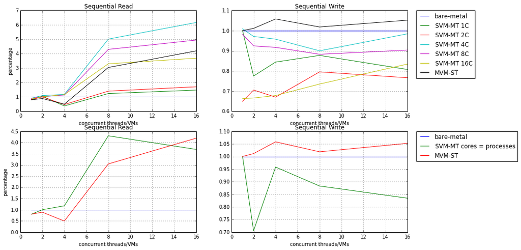

```python
pylab.rcParams['figure.figsize'] = 14, 8  # change default size of figures
x_axis = [1,2,4,8,16]

plt.subplot(221)
plt.plot(x_axis, nml_aggbwsrbf, label = 'bare-metal')
plt.plot(x_axis, nml_aggbwsrsvm1c, label = 'SVM-MT 1C')
plt.plot(x_axis, nml_aggbwsrsvm2c, label = 'SVM-MT 2C')
plt.plot(x_axis, nml_aggbwsrsvm4c, label = 'SVM-MT 4C')
plt.plot(x_axis, nml_aggbwsrsvm8c, label = 'SVM-MT 8C')
plt.plot(x_axis, nml_aggbwsrsvm16c, label = 'SVM-MT 16C')
plt.plot(x_axis, nml_aggbwsrmvm, label = 'MVM-ST')
#plt.axis([1, 16, 0, 1.5])
plt.grid(True)
plt.title('Sequential Read')
pylab.xlabel('concurrent threads/VMs')
pylab.ylabel('percentage')

plt.subplot(222)
plt.plot(x_axis, nml_aggbwswbf, label = 'bare-metal')
plt.plot(x_axis, nml_aggbwswsvm1c, label = 'SVM-MT 1C')
plt.plot(x_axis, nml_aggbwswsvm2c, label = 'SVM-MT 2C')
plt.plot(x_axis, nml_aggbwswsvm4c, label = 'SVM-MT 4C')
plt.plot(x_axis, nml_aggbwswsvm8c, label = 'SVM-MT 8C')
plt.plot(x_axis, nml_aggbwswsvm16c, label = 'SVM-MT 16C')
plt.plot(x_axis, nml_aggbwswmvm, label = 'MVM-ST')
#plt.axis([1, 16, 0, 1.5])
plt.grid(True)
plt.title('Sequential Write')
plt.legend(bbox_to_anchor=(1.05, 1), loc=2, borderaxespad=0.)
pylab.xlabel('concurrent threads/VMs')
#pylab.ylabel('percentage')

plt.subplot(223)
plt.plot(x_axis, nml_aggbwsrbf, label = 'bare-metal')
plt.plot(x_axis, nml_aggbwsrsvm, label = 'SVM-MT cores = processes')
plt.plot(x_axis, nml_aggbwsrmvm, label = 'MVM-ST')
#plt.axis([1, 16, 0, 1.5])
plt.grid(True)
plt.title('Sequential Read')
pylab.xlabel('concurrent threads/VMs')
pylab.ylabel('percentage')

plt.subplot(224)
plt.plot(x_axis, nml_aggbwswbf, label = 'bare-metal')
plt.plot(x_axis, nml_aggbwswsvm, label = 'SVM-MT cores = processes ')
plt.plot(x_axis, nml_aggbwswmvm, label = 'MVM-ST')
#plt.axis([1, 16, 0, 1.5])
plt.grid(True)
plt.title('Sequential Write')
plt.legend(bbox_to_anchor=(1.05, 1), loc=2, borderaxespad=0.)
pylab.xlabel('concurrent threads/VMs')

#plt.savefig('nml_throughput16procs.pdf')
```

## Jain Fairness Index

```python
jfi = dtdata.T.sum()**2/dtdata.T.count()/(dtdata**2).T.sum() #Calculate Jair Fairness Index for each test
jfigrouped = jfi.groupby(level=0)
jfiavg = jfigrouped.mean() # Calculate JFI average from 5 tests

# for plotting confident interval
# jfistd = jfigrouped.std() # Standard Deviation
cijfi = jfigrouped.aggregate(lambda x: np.std(x) / np.sqrt(x.count()) * 1.96) # Confident interval of 95%

# prepare for plotting
jfisrbf = jfiavg.filter(regex="^SRBFTH").tolist()
jfiswbf = jfiavg.filter(regex="^SWBFTH").tolist()

jfisrsvm1c = jfiavg.filter(regex="^SR01VM01CTH").tolist()
jfiswsvm1c = jfiavg.filter(regex="^SW01VM01CTH").tolist()
jfisrsvm2c = jfiavg.filter(regex="^SR01VM02CTH").tolist()
jfiswsvm2c = jfiavg.filter(regex="^SW01VM02CTH").tolist()
jfisrsvm4c = jfiavg.filter(regex="^SR01VM04CTH").tolist()
jfiswsvm4c = jfiavg.filter(regex="^SW01VM04CTH").tolist()
jfisrsvm8c = jfiavg.filter(regex="^SR01VM08CTH").tolist()
jfiswsvm8c = jfiavg.filter(regex="^SW01VM08CTH").tolist()
jfisrsvm16c = jfiavg.filter(regex="^SR01VM16CTH").tolist()
jfiswsvm16c = jfiavg.filter(regex="^SW01VM16CTH").tolist()

jfisrmvm = jfiavg.filter(regex="^SR[0-9]+VM01CTH01").tolist()
jfiswmvm = jfiavg.filter(regex="^SW[0-9]+VM01CTH01").tolist()


cijfisrbf = cijfi.filter(regex="^SRBFTH").tolist()
cijfiswbf = cijfi.filter(regex="^SWBFTH").tolist()

cijfisrsvm1c = cijfi.filter(regex="^SR01VM01CTH").tolist()
cijfiswsvm1c = cijfi.filter(regex="^SW01VM01CTH").tolist()
cijfisrsvm2c = cijfi.filter(regex="^SR01VM02CTH").tolist()
cijfiswsvm2c = cijfi.filter(regex="^SW01VM02CTH").tolist()
cijfisrsvm4c = cijfi.filter(regex="^SR01VM04CTH").tolist()
cijfiswsvm4c = cijfi.filter(regex="^SW01VM04CTH").tolist()
cijfisrsvm8c = cijfi.filter(regex="^SR01VM08CTH").tolist()
cijfiswsvm8c = cijfi.filter(regex="^SW01VM08CTH").tolist()
cijfisrsvm16c = cijfi.filter(regex="^SR01VM16CTH").tolist()
cijfiswsvm16c = cijfi.filter(regex="^SW01VM16CTH").tolist()

cijfisrmvm = cijfi.filter(regex="^SR[0-9]+VM01CTH01").tolist()
cijfiswmvm = cijfi.filter(regex="^SW[0-9]+VM01CTH01").tolist()

# Cores = Processes
jfisrsvm = [jfisrsvm1c[0], jfisrsvm2c[1], jfisrsvm4c[2], jfisrsvm8c[3], jfisrsvm16c[4]]
jfiswsvm = [jfiswsvm1c[0], jfiswsvm2c[1], jfiswsvm4c[2], jfiswsvm8c[3], jfiswsvm16c[4]]
cijfisrsvm = [cijfisrsvm1c[0], cijfisrsvm2c[1], cijfisrsvm4c[2], cijfisrsvm8c[3], cijfisrsvm16c[4]]
cijfiswsvm = [cijfiswsvm1c[0], cijfiswsvm2c[1], cijfiswsvm4c[2], cijfiswsvm8c[3], cijfiswsvm16c[4]]
```

```
 <a list of 5 Text xticklabel objects>)
```

[figure not shown]

```python
pylab.rcParams['figure.figsize'] = 14, 8  # change default size of figures
x_axis = [1,2,4,8,16]

plt.subplot(221)
plt.errorbar(x_axis, jfisrbf, cijfisrbf, label = 'bare-metal')
plt.errorbar(x_axis, jfisrsvm1c, cijfisrsvm1c, label = 'SVM-MT 1C')
plt.errorbar(x_axis, jfisrsvm2c, cijfisrsvm2c, label = 'SVM-MT 2C')
plt.errorbar(x_axis, jfisrsvm4c, cijfisrsvm4c, label = 'SVM-MT 4C')
plt.errorbar(x_axis, jfisrsvm8c, cijfisrsvm8c, label = 'SVM-MT 8C')
plt.errorbar(x_axis, jfisrsvm16c, cijfisrsvm16c, label = 'SVM-MT 16C')
plt.errorbar(x_axis, jfisrmvm, cijfisrmvm, label = 'MVM-ST')
plt.axis([0.9, 4.1, 0.5, 1.03])
plt.grid(True)
plt.title('Sequential Read')
plt.xlabel('concurrent threads/VMs')
plt.ylabel('Jain Fairness Index')
plt.xticks(x_axis)

plt.subplot(222)
plt.errorbar(x_axis, jfiswbf, cijfiswbf, label = 'bare-metal')
plt.errorbar(x_axis, jfiswsvm1c, cijfiswsvm1c, label = 'SVM-MT 1C')
plt.errorbar(x_axis, jfiswsvm2c, cijfiswsvm2c, label = 'SVM-MT 2C')
plt.errorbar(x_axis, jfiswsvm4c, cijfiswsvm4c, label = 'SVM-MT 4C')
plt.errorbar(x_axis, jfiswsvm8c, cijfiswsvm8c, label = 'SVM-MT 8C')
plt.errorbar(x_axis, jfiswsvm16c, cijfiswsvm16c, label = 'SVM-MT 16C')
plt.errorbar(x_axis, jfiswmvm, cijfiswmvm, label = 'MVM-ST')
plt.axis([0.9, 4.1, 0.5, 1.03])
plt.grid(True)
plt.title('Sequential Write')
plt.xlabel('concurrent threads/VMs')
plt.legend(bbox_to_anchor=(1.05, 1), loc=2, borderaxespad=0.)
#plt.ylabel('JFI index')
plt.xticks(x_axis)

plt.subplot(223)
plt.errorbar(x_axis, jfisrbf, cijfisrbf, color="blue", label = 'bare-metal')
plt.errorbar(x_axis, jfisrsvm, cijfisrsvm, color="green", label = 'SVM-MT cores = processes')
plt.errorbar(x_axis, jfisrmvm, cijfisrmvm, color="black", label = 'MVM-ST')
plt.axis([0.9, 4.1, 0.5, 1.03])
plt.grid(True)
plt.title('Sequential Read')
plt.xlabel('concurrent threads/VMs')
plt.ylabel('Jain Fairness Index')
plt.xticks(x_axis)

plt.subplot(224)
plt.errorbar(x_axis, jfiswbf, cijfiswbf, color="blue", label = 'bare-metal')
plt.errorbar(x_axis, jfiswsvm, cijfiswsvm, color="green", label = 'SVM-MT cores = processes')
plt.errorbar(x_axis, jfiswmvm, cijfiswmvm,color="black", label = 'MVM-ST')
plt.axis([0.9, 4.1, 0.5, 1.03])
plt.grid(True)
plt.title('Sequential Write')
plt.xlabel('concurrent threads/VMs')
plt.legend(bbox_to_anchor=(1.05, 1), loc=2, borderaxespad=0.)
#plt.ylabel('JFI index')
plt.xticks(x_axis)

#plt.savefig('jfi16procs.pdf')
```

## CPU Utilization

## Context Switching

## IOPS

## Latency

## Disk Utilization

## Cache Affection

```python
dtresult = pd.read_csv('data/bwbm16p4g_sda.csv', delimiter=' ', header=None)
dtdata = dtresult[range(1,17)]
dtindex = dtresult[0]
dtdata.index = dtindex.str.replace('T[0-2][0-9]', '',case=False)

# To calculate the average throughput, we first calculate average throughput each thread has in one test, then again take the
# average of 10 tests
avgtpin1test = dtdata.T.mean() # Average throughput of each thread/VM in one test
avgtpin5tests = avgtpin1test.groupby(level=0).mean() # Average throughput of each thread/VM in 5 tests
avgtpin5tests = avgtpin5tests / 1024 # Converting to Megabytes/second
# Putting average throughput per thread/VM to vector before plotting
bwsrbf7sda = avgtpin5tests.filter(regex="^SRBFTH").tolist()
bwswbf7sda = avgtpin5tests.filter(regex="^SWBFTH").tolist()

# Calculate aggregated throughput on each host of each test, then taking the average
aggtpin1test = dtdata.T.sum() # Aggregate throughput on each host in one test
avgaggtpintestgrouped = aggtpin1test.groupby(level=0)
avgaggtpin5tests = avgaggtpintestgrouped.mean() # Then calculate the average of the total throughput through 5 tests
avgaggtpin5tests = avgaggtpin5tests / 1024 # Convert to MB/s
ciaggtpin5tests = avgaggtpintestgrouped.aggregate(lambda x: np.std(x) / np.sqrt(x.count()) * 1.96) # Confident interval of 95%
ciaggtpin5tests = ciaggtpin5tests / 1024 # Convert to same scale with mean

# Putting average aggregate throughput to vector before plotting
aggbwsrbf7sda = avgaggtpin5tests.filter(regex="^SRBFTH").tolist()
aggbwswbf7sda = avgaggtpin5tests.filter(regex="^SWBFTH").tolist()
ciaggbwsrbf7sda = ciaggtpin5tests.filter(regex="^SRBFTH").tolist()
ciaggbwswbf7sda = ciaggtpin5tests.filter(regex="^SWBFTH").tolist()
```

```python
dtresult = pd.read_csv('data/bwbm16p4g_sdf.csv', delimiter=' ', header=None)
dtdata = dtresult[range(1,17)]
dtindex = dtresult[0]
dtdata.index = dtindex.str.replace('T[0-2][0-9]', '',case=False)

# To calculate the average throughput, we first calculate average throughput each thread has in one test, then again take the
# average of 10 tests
avgtpin1test = dtdata.T.mean() # Average throughput of each thread/VM in one test
avgtpin5tests = avgtpin1test.groupby(level=0).mean() # Average throughput of each thread/VM in 5 tests
avgtpin5tests = avgtpin5tests / 1024 # Converting to Megabytes/second
# Putting average throughput per thread/VM to vector before plotting
bwsrbf7sdf = avgtpin5tests.filter(regex="^SRBFTH").tolist()
bwswbf7sdf = avgtpin5tests.filter(regex="^SWBFTH").tolist()

# Calculate aggregated throughput on each host of each test, then taking the average
aggtpin1test = dtdata.T.sum() # Aggregate throughput on each host in one test
avgaggtpintestgrouped = aggtpin1test.groupby(level=0)
avgaggtpin5tests = avgaggtpintestgrouped.mean() # Then calculate the average of the total throughput through 5 tests
avgaggtpin5tests = avgaggtpin5tests / 1024 # Convert to MB/s
ciaggtpin5tests = avgaggtpintestgrouped.aggregate(lambda x: np.std(x) / np.sqrt(x.count()) * 1.96) # Confident interval of 95%
ciaggtpin5tests = ciaggtpin5tests / 1024 # Convert to same scale with mean

# Putting average aggregate throughput to vector before plotting
aggbwsrbf7sdf = avgaggtpin5tests.filter(regex="^SRBFTH").tolist()
aggbwswbf7sdf = avgaggtpin5tests.filter(regex="^SWBFTH").tolist()
ciaggbwsrbf7sdf = ciaggtpin5tests.filter(regex="^SRBFTH").tolist()
ciaggbwswbf7sdf = ciaggtpin5tests.filter(regex="^SWBFTH").tolist()
```

```python
dtresult = pd.read_csv('data/bwbm16p4g_sdg.csv', delimiter=' ', header=None)
dtdata = dtresult[range(1,17)]
dtindex = dtresult[0]
dtdata.index = dtindex.str.replace('T[0-2][0-9]', '',case=False)

# To calculate the average throughput, we first calculate average throughput each thread has in one test, then again take the
# average of 10 tests
avgtpin1test = dtdata.T.mean() # Average throughput of each thread/VM in one test
avgtpin5tests = avgtpin1test.groupby(level=0).mean() # Average throughput of each thread/VM in 5 tests
avgtpin5tests = avgtpin5tests / 1024 # Converting to Megabytes/second
# Putting average throughput per thread/VM to vector before plotting
bwsrbf7sdg = avgtpin5tests.filter(regex="^SRBFTH").tolist()
bwswbf7sdg = avgtpin5tests.filter(regex="^SWBFTH").tolist()

# Calculate aggregated throughput on each host of each test, then taking the average
aggtpin1test = dtdata.T.sum() # Aggregate throughput on each host in one test
avgaggtpintestgrouped = aggtpin1test.groupby(level=0)
avgaggtpin5tests = avgaggtpintestgrouped.mean() # Then calculate the average of the total throughput through 5 tests
avgaggtpin5tests = avgaggtpin5tests / 1024 # Convert to MB/s
ciaggtpin5tests = avgaggtpintestgrouped.aggregate(lambda x: np.std(x) / np.sqrt(x.count()) * 1.96) # Confident interval of 95%
ciaggtpin5tests = ciaggtpin5tests / 1024 # Convert to same scale with mean

# Putting average aggregate throughput to vector before plotting
aggbwsrbf7sdg = avgaggtpin5tests.filter(regex="^SRBFTH").tolist()
aggbwswbf7sdg = avgaggtpin5tests.filter(regex="^SWBFTH").tolist()
ciaggbwsrbf7sdg = ciaggtpin5tests.filter(regex="^SRBFTH").tolist()
ciaggbwswbf7sdg = ciaggtpin5tests.filter(regex="^SWBFTH").tolist()
```

```python
dtresult = pd.read_csv('data/bwbm16p4g_sdh.csv', delimiter=' ', header=None)
dtdata = dtresult[range(1,17)]
dtindex = dtresult[0]
dtdata.index = dtindex.str.replace('T[0-2][0-9]', '',case=False)

# To calculate the average throughput, we first calculate average throughput each thread has in one test, then again take the
# average of 10 tests
avgtpin1test = dtdata.T.mean() # Average throughput of each thread/VM in one test
avgtpin5tests = avgtpin1test.groupby(level=0).mean() # Average throughput of each thread/VM in 5 tests
avgtpin5tests = avgtpin5tests / 1024 # Converting to Megabytes/second
# Putting average throughput per thread/VM to vector before plotting
bwsrbf7sdh = avgtpin5tests.filter(regex="^SRBFTH").tolist()
bwswbf7sdh = avgtpin5tests.filter(regex="^SWBFTH").tolist()

# Calculate aggregated throughput on each host of each test, then taking the average
aggtpin1test = dtdata.T.sum() # Aggregate throughput on each host in one test
avgaggtpintestgrouped = aggtpin1test.groupby(level=0)
avgaggtpin5tests = avgaggtpintestgrouped.mean() # Then calculate the average of the total throughput through 5 tests
avgaggtpin5tests = avgaggtpin5tests / 1024 # Convert to MB/s
ciaggtpin5tests = avgaggtpintestgrouped.aggregate(lambda x: np.std(x) / np.sqrt(x.count()) * 1.96) # Confident interval of 95%
ciaggtpin5tests = ciaggtpin5tests / 1024 # Convert to same scale with mean

# Putting average aggregate throughput to vector before plotting
aggbwsrbf7sdh = avgaggtpin5tests.filter(regex="^SRBFTH").tolist()
aggbwswbf7sdh = avgaggtpin5tests.filter(regex="^SWBFTH").tolist()
ciaggbwsrbf7sdh = ciaggtpin5tests.filter(regex="^SRBFTH").tolist()
ciaggbwswbf7sdh = ciaggtpin5tests.filter(regex="^SWBFTH").tolist()
```

```python
dtresult = pd.read_csv('data/bwbm16p4g_sdi.csv', delimiter=' ', header=None)
dtdata = dtresult[range(1,17)]
dtindex = dtresult[0]
dtdata.index = dtindex.str.replace('T[0-2][0-9]', '',case=False)

# To calculate the average throughput, we first calculate average throughput each thread has in one test, then again take the
# average of 10 tests
avgtpin1test = dtdata.T.mean() # Average throughput of each thread/VM in one test
avgtpin5tests = avgtpin1test.groupby(level=0).mean() # Average throughput of each thread/VM in 5 tests
avgtpin5tests = avgtpin5tests / 1024 # Converting to Megabytes/second
# Putting average throughput per thread/VM to vector before plotting
bwsrbf7sdi = avgtpin5tests.filter(regex="^SRBFTH").tolist()
bwswbf7sdi = avgtpin5tests.filter(regex="^SWBFTH").tolist()

# Calculate aggregated throughput on each host of each test, then taking the average
aggtpin1test = dtdata.T.sum() # Aggregate throughput on each host in one test
avgaggtpintestgrouped = aggtpin1test.groupby(level=0)
avgaggtpin5tests = avgaggtpintestgrouped.mean() # Then calculate the average of the total throughput through 5 tests
avgaggtpin5tests = avgaggtpin5tests / 1024 # Convert to MB/s
ciaggtpin5tests = avgaggtpintestgrouped.aggregate(lambda x: np.std(x) / np.sqrt(x.count()) * 1.96) # Confident interval of 95%
ciaggtpin5tests = ciaggtpin5tests / 1024 # Convert to same scale with mean

# Putting average aggregate throughput to vector before plotting
aggbwsrbf7sdi = avgaggtpin5tests.filter(regex="^SRBFTH").tolist()
aggbwswbf7sdi = avgaggtpin5tests.filter(regex="^SWBFTH").tolist()
ciaggbwsrbf7sdi = ciaggtpin5tests.filter(regex="^SRBFTH").tolist()
ciaggbwswbf7sdi = ciaggtpin5tests.filter(regex="^SWBFTH").tolist()
```

```python
dtresult = pd.read_csv('data/bwbm16p4g_sdj.csv', delimiter=' ', header=None)
dtdata = dtresult[range(1,17)]
dtindex = dtresult[0]
dtdata.index = dtindex.str.replace('T[0-2][0-9]', '',case=False)

# To calculate the average throughput, we first calculate average throughput each thread has in one test, then again take the
# average of 10 tests
avgtpin1test = dtdata.T.mean() # Average throughput of each thread/VM in one test
avgtpin5tests = avgtpin1test.groupby(level=0).mean() # Average throughput of each thread/VM in 5 tests
avgtpin5tests = avgtpin5tests / 1024 # Converting to Megabytes/second
# Putting average throughput per thread/VM to vector before plotting
bwsrbf7sdj = avgtpin5tests.filter(regex="^SRBFTH").tolist()
bwswbf7sdj = avgtpin5tests.filter(regex="^SWBFTH").tolist()

# Calculate aggregated throughput on each host of each test, then taking the average
aggtpin1test = dtdata.T.sum() # Aggregate throughput on each host in one test
avgaggtpintestgrouped = aggtpin1test.groupby(level=0)
avgaggtpin5tests = avgaggtpintestgrouped.mean() # Then calculate the average of the total throughput through 5 tests
avgaggtpin5tests = avgaggtpin5tests / 1024 # Convert to MB/s
ciaggtpin5tests = avgaggtpintestgrouped.aggregate(lambda x: np.std(x) / np.sqrt(x.count()) * 1.96) # Confident interval of 95%
ciaggtpin5tests = ciaggtpin5tests / 1024 # Convert to same scale with mean

# Putting average aggregate throughput to vector before plotting
aggbwsrbf7sdj = avgaggtpin5tests.filter(regex="^SRBFTH").tolist()
aggbwswbf7sdj = avgaggtpin5tests.filter(regex="^SWBFTH").tolist()
ciaggbwsrbf7sdj = ciaggtpin5tests.filter(regex="^SRBFTH").tolist()
ciaggbwswbf7sdj = ciaggtpin5tests.filter(regex="^SWBFTH").tolist()
```

```python
dtresult = pd.read_csv('data/bwbm16p4glvm_sda.csv', delimiter=' ', header=None)
dtdata = dtresult[range(1,17)]
dtindex = dtresult[0]
dtdata.index = dtindex.str.replace('T[0-2][0-9]', '',case=False)

# To calculate the average throughput, we first calculate average throughput each thread has in one test, then again take the
# average of 10 tests
avgtpin1test = dtdata.T.mean() # Average throughput of each thread/VM in one test
avgtpin5tests = avgtpin1test.groupby(level=0).mean() # Average throughput of each thread/VM in 5 tests
avgtpin5tests = avgtpin5tests / 1024 # Converting to Megabytes/second
# Putting average throughput per thread/VM to vector before plotting
bwsrbf7lvmsda = avgtpin5tests.filter(regex="^SRBFTH").tolist()
bwswbf7lvmsda = avgtpin5tests.filter(regex="^SWBFTH").tolist()

# Calculate aggregated throughput on each host of each test, then taking the average
aggtpin1test = dtdata.T.sum() # Aggregate throughput on each host in one test
avgaggtpintestgrouped = aggtpin1test.groupby(level=0)
avgaggtpin5tests = avgaggtpintestgrouped.mean() # Then calculate the average of the total throughput through 5 tests
avgaggtpin5tests = avgaggtpin5tests / 1024 # Convert to MB/s
ciaggtpin5tests = avgaggtpintestgrouped.aggregate(lambda x: np.std(x) / np.sqrt(x.count()) * 1.96) # Confident interval of 95%
ciaggtpin5tests = ciaggtpin5tests / 1024 # Convert to same scale with mean

# Putting average aggregate throughput to vector before plotting
aggbwsrbf7lvmsda = avgaggtpin5tests.filter(regex="^SRBFTH").tolist()
aggbwswbf7lvmsda = avgaggtpin5tests.filter(regex="^SWBFTH").tolist()
ciaggbwsrbf7lvmsda = ciaggtpin5tests.filter(regex="^SRBFTH").tolist()
ciaggbwswbf7lvmsda = ciaggtpin5tests.filter(regex="^SWBFTH").tolist()
```

```python
dtresult = pd.read_csv('data/bwbm16p4glvm_sdf.csv', delimiter=' ', header=None)
dtdata = dtresult[range(1,17)]
dtindex = dtresult[0]
dtdata.index = dtindex.str.replace('T[0-2][0-9]', '',case=False)

# To calculate the average throughput, we first calculate average throughput each thread has in one test, then again take the
# average of 10 tests
avgtpin1test = dtdata.T.mean() # Average throughput of each thread/VM in one test
avgtpin5tests = avgtpin1test.groupby(level=0).mean() # Average throughput of each thread/VM in 5 tests
avgtpin5tests = avgtpin5tests / 1024 # Converting to Megabytes/second
# Putting average throughput per thread/VM to vector before plotting
bwsrbf7lvmsdf = avgtpin5tests.filter(regex="^SRBFTH").tolist()
bwswbf7lvmsdf = avgtpin5tests.filter(regex="^SWBFTH").tolist()

# Calculate aggregated throughput on each host of each test, then taking the average
aggtpin1test = dtdata.T.sum() # Aggregate throughput on each host in one test
avgaggtpintestgrouped = aggtpin1test.groupby(level=0)
avgaggtpin5tests = avgaggtpintestgrouped.mean() # Then calculate the average of the total throughput through 5 tests
avgaggtpin5tests = avgaggtpin5tests / 1024 # Convert to MB/s
ciaggtpin5tests = avgaggtpintestgrouped.aggregate(lambda x: np.std(x) / np.sqrt(x.count()) * 1.96) # Confident interval of 95%
ciaggtpin5tests = ciaggtpin5tests / 1024 # Convert to same scale with mean

# Putting average aggregate throughput to vector before plotting
aggbwsrbf7lvmsdf = avgaggtpin5tests.filter(regex="^SRBFTH").tolist()
aggbwswbf7lvmsdf = avgaggtpin5tests.filter(regex="^SWBFTH").tolist()
ciaggbwsrbf7lvmsdf = ciaggtpin5tests.filter(regex="^SRBFTH").tolist()
ciaggbwswbf7lvmsdf = ciaggtpin5tests.filter(regex="^SWBFTH").tolist()
```

```python
dtresult = pd.read_csv('data/bwbm16p4glvm_sdg.csv', delimiter=' ', header=None)
dtdata = dtresult[range(1,17)]
dtindex = dtresult[0]
dtdata.index = dtindex.str.replace('T[0-2][0-9]', '',case=False)

# To calculate the average throughput, we first calculate average throughput each thread has in one test, then again take the
# average of 10 tests
avgtpin1test = dtdata.T.mean() # Average throughput of each thread/VM in one test
avgtpin5tests = avgtpin1test.groupby(level=0).mean() # Average throughput of each thread/VM in 5 tests
avgtpin5tests = avgtpin5tests / 1024 # Converting to Megabytes/second
# Putting average throughput per thread/VM to vector before plotting
bwsrbf7lvmsdg = avgtpin5tests.filter(regex="^SRBFTH").tolist()
bwswbf7lvmsdg = avgtpin5tests.filter(regex="^SWBFTH").tolist()

# Calculate aggregated throughput on each host of each test, then taking the average
aggtpin1test = dtdata.T.sum() # Aggregate throughput on each host in one test
avgaggtpintestgrouped = aggtpin1test.groupby(level=0)
avgaggtpin5tests = avgaggtpintestgrouped.mean() # Then calculate the average of the total throughput through 5 tests
avgaggtpin5tests = avgaggtpin5tests / 1024 # Convert to MB/s
ciaggtpin5tests = avgaggtpintestgrouped.aggregate(lambda x: np.std(x) / np.sqrt(x.count()) * 1.96) # Confident interval of 95%
ciaggtpin5tests = ciaggtpin5tests / 1024 # Convert to same scale with mean

# Putting average aggregate throughput to vector before plotting
aggbwsrbf7lvmsdg = avgaggtpin5tests.filter(regex="^SRBFTH").tolist()
aggbwswbf7lvmsdg = avgaggtpin5tests.filter(regex="^SWBFTH").tolist()
ciaggbwsrbf7lvmsdg = ciaggtpin5tests.filter(regex="^SRBFTH").tolist()
ciaggbwswbf7lvmsdg = ciaggtpin5tests.filter(regex="^SWBFTH").tolist()
```

```python
dtresult = pd.read_csv('data/bwbm16p4glvm_sdh.csv', delimiter=' ', header=None)
dtdata = dtresult[range(1,17)]
dtindex = dtresult[0]
dtdata.index = dtindex.str.replace('T[0-2][0-9]', '',case=False)

# To calculate the average throughput, we first calculate average throughput each thread has in one test, then again take the
# average of 10 tests
avgtpin1test = dtdata.T.mean() # Average throughput of each thread/VM in one test
avgtpin5tests = avgtpin1test.groupby(level=0).mean() # Average throughput of each thread/VM in 5 tests
avgtpin5tests = avgtpin5tests / 1024 # Converting to Megabytes/second
# Putting average throughput per thread/VM to vector before plotting
bwsrbf7lvmsdh = avgtpin5tests.filter(regex="^SRBFTH").tolist()
bwswbf7lvmsdh = avgtpin5tests.filter(regex="^SWBFTH").tolist()

# Calculate aggregated throughput on each host of each test, then taking the average
aggtpin1test = dtdata.T.sum() # Aggregate throughput on each host in one test
avgaggtpintestgrouped = aggtpin1test.groupby(level=0)
avgaggtpin5tests = avgaggtpintestgrouped.mean() # Then calculate the average of the total throughput through 5 tests
avgaggtpin5tests = avgaggtpin5tests / 1024 # Convert to MB/s
ciaggtpin5tests = avgaggtpintestgrouped.aggregate(lambda x: np.std(x) / np.sqrt(x.count()) * 1.96) # Confident interval of 95%
ciaggtpin5tests = ciaggtpin5tests / 1024 # Convert to same scale with mean

# Putting average aggregate throughput to vector before plotting
aggbwsrbf7lvmsdh = avgaggtpin5tests.filter(regex="^SRBFTH").tolist()
aggbwswbf7lvmsdh = avgaggtpin5tests.filter(regex="^SWBFTH").tolist()
ciaggbwsrbf7lvmsdh = ciaggtpin5tests.filter(regex="^SRBFTH").tolist()
ciaggbwswbf7lvmsdh = ciaggtpin5tests.filter(regex="^SWBFTH").tolist()
```

```python
dtresult = pd.read_csv('data/bwbm16p4glvm_sdi.csv', delimiter=' ', header=None)
dtdata = dtresult[range(1,17)]
dtindex = dtresult[0]
dtdata.index = dtindex.str.replace('T[0-2][0-9]', '',case=False)

# To calculate the average throughput, we first calculate average throughput each thread has in one test, then again take the
# average of 10 tests
avgtpin1test = dtdata.T.mean() # Average throughput of each thread/VM in one test
avgtpin5tests = avgtpin1test.groupby(level=0).mean() # Average throughput of each thread/VM in 5 tests
avgtpin5tests = avgtpin5tests / 1024 # Converting to Megabytes/second
# Putting average throughput per thread/VM to vector before plotting
bwsrbf7lvmsdi = avgtpin5tests.filter(regex="^SRBFTH").tolist()
bwswbf7lvmsdi = avgtpin5tests.filter(regex="^SWBFTH").tolist()

# Calculate aggregated throughput on each host of each test, then taking the average
aggtpin1test = dtdata.T.sum() # Aggregate throughput on each host in one test
avgaggtpintestgrouped = aggtpin1test.groupby(level=0)
avgaggtpin5tests = avgaggtpintestgrouped.mean() # Then calculate the average of the total throughput through 5 tests
avgaggtpin5tests = avgaggtpin5tests / 1024 # Convert to MB/s
ciaggtpin5tests = avgaggtpintestgrouped.aggregate(lambda x: np.std(x) / np.sqrt(x.count()) * 1.96) # Confident interval of 95%
ciaggtpin5tests = ciaggtpin5tests / 1024 # Convert to same scale with mean

# Putting average aggregate throughput to vector before plotting
aggbwsrbf7lvmsdi = avgaggtpin5tests.filter(regex="^SRBFTH").tolist()
aggbwswbf7lvmsdi = avgaggtpin5tests.filter(regex="^SWBFTH").tolist()
ciaggbwsrbf7lvmsdi = ciaggtpin5tests.filter(regex="^SRBFTH").tolist()
ciaggbwswbf7lvmsdi = ciaggtpin5tests.filter(regex="^SWBFTH").tolist()
```

```python
dtresult = pd.read_csv('data/bwbm16p4glvm_sdj.csv', delimiter=' ', header=None)
dtdata = dtresult[range(1,17)]
dtindex = dtresult[0]
dtdata.index = dtindex.str.replace('T[0-2][0-9]', '',case=False)

# To calculate the average throughput, we first calculate average throughput each thread has in one test, then again take the
# average of 10 tests
avgtpin1test = dtdata.T.mean() # Average throughput of each thread/VM in one test
avgtpin5tests = avgtpin1test.groupby(level=0).mean() # Average throughput of each thread/VM in 5 tests
avgtpin5tests = avgtpin5tests / 1024 # Converting to Megabytes/second
# Putting average throughput per thread/VM to vector before plotting
bwsrbf7lvmsdj = avgtpin5tests.filter(regex="^SRBFTH").tolist()
bwswbf7lvmsdj = avgtpin5tests.filter(regex="^SWBFTH").tolist()

# Calculate aggregated throughput on each host of each test, then taking the average
aggtpin1test = dtdata.T.sum() # Aggregate throughput on each host in one test
avgaggtpintestgrouped = aggtpin1test.groupby(level=0)
avgaggtpin5tests = avgaggtpintestgrouped.mean() # Then calculate the average of the total throughput through 5 tests
avgaggtpin5tests = avgaggtpin5tests / 1024 # Convert to MB/s
ciaggtpin5tests = avgaggtpintestgrouped.aggregate(lambda x: np.std(x) / np.sqrt(x.count()) * 1.96) # Confident interval of 95%
ciaggtpin5tests = ciaggtpin5tests / 1024 # Convert to same scale with mean

# Putting average aggregate throughput to vector before plotting
aggbwsrbf7lvmsdj = avgaggtpin5tests.filter(regex="^SRBFTH").tolist()
aggbwswbf7lvmsdj = avgaggtpin5tests.filter(regex="^SWBFTH").tolist()
ciaggbwsrbf7lvmsdj = ciaggtpin5tests.filter(regex="^SRBFTH").tolist()
ciaggbwswbf7lvmsdj = ciaggtpin5tests.filter(regex="^SWBFTH").tolist()
```

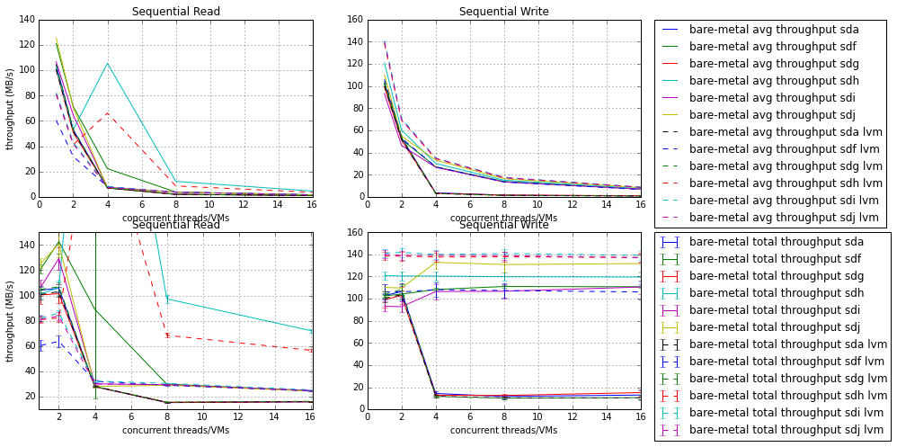

```python
x_axis = [1,2,4,8,16]
pylab.rcParams['figure.figsize'] = 12, 12  # change default size of figures
plt.subplot(321)
plt.plot(x_axis, bwsrbf7sda)
plt.plot(x_axis, bwsrbf7sdf)
plt.plot(x_axis, bwsrbf7sdg)
plt.plot(x_axis, bwsrbf7sdh)
plt.plot(x_axis, bwsrbf7sdi)
plt.plot(x_axis, bwsrbf7sdj)
plt.plot(x_axis, bwsrbf7lvmsda, ls="dashed",)
plt.plot(x_axis, bwsrbf7lvmsdf, ls="dashed",)
plt.plot(x_axis, bwsrbf7lvmsdg, ls="dashed",)
plt.plot(x_axis, bwsrbf7lvmsdh, ls="dashed",)
plt.plot(x_axis, bwsrbf7lvmsdi, ls="dashed",)
plt.plot(x_axis, bwsrbf7lvmsdj, ls="dashed",)
#plt.axis([0.9, 16.1, 0, 150])
plt.grid(True)
plt.title('Sequential Read')
pylab.xlabel('concurrent threads/VMs')
pylab.ylabel('throughput (MB/s)')

plt.subplot(322)
plt.plot(x_axis, bwswbf7sda, label = 'bare-metal avg throughput sda')
plt.plot(x_axis, bwswbf7sdf, label = 'bare-metal avg throughput sdf')
plt.plot(x_axis, bwswbf7sdg, label = 'bare-metal avg throughput sdg')
plt.plot(x_axis, bwswbf7sdh, label = 'bare-metal avg throughput sdh')
plt.plot(x_axis, bwswbf7sdi, label = 'bare-metal avg throughput sdi')
plt.plot(x_axis, bwswbf7sdj, label = 'bare-metal avg throughput sdj')
plt.plot(x_axis, bwswbf7lvmsda, ls="dashed", label = 'bare-metal avg throughput sda lvm')
plt.plot(x_axis, bwswbf7lvmsdf, ls="dashed", label = 'bare-metal avg throughput sdf lvm')
plt.plot(x_axis, bwswbf7lvmsdg, ls="dashed", label = 'bare-metal avg throughput sdg lvm')
plt.plot(x_axis, bwswbf7lvmsdh, ls="dashed", label = 'bare-metal avg throughput sdh lvm')
plt.plot(x_axis, bwswbf7lvmsdi, ls="dashed", label = 'bare-metal avg throughput sdi lvm')
plt.plot(x_axis, bwswbf7lvmsdj, ls="dashed", label = 'bare-metal avg throughput sdj lvm')
#plt.axis([0.9, 16.1, 0, 150])
plt.grid(True)
plt.legend(bbox_to_anchor=(1.05, 1), loc=2, borderaxespad=0.)
plt.title('Sequential Write')
pylab.xlabel('concurrent threads/VMs')
#pylab.ylabel('throughput (MB/s)')

plt.subplot(323)
plt.errorbar(x_axis, aggbwsrbf7sda, ciaggbwsrbf7sda)
plt.errorbar(x_axis, aggbwsrbf7sdf, ciaggbwsrbf7sdf)
plt.errorbar(x_axis, aggbwsrbf7sdg, ciaggbwsrbf7sdg)
plt.errorbar(x_axis, aggbwsrbf7sdh, ciaggbwsrbf7sdh)
plt.errorbar(x_axis, aggbwsrbf7sdi, ciaggbwsrbf7sdi)
plt.errorbar(x_axis, aggbwsrbf7sdj, ciaggbwsrbf7sdj)
plt.errorbar(x_axis, aggbwsrbf7lvmsda, ciaggbwsrbf7lvmsda, ls="dashed",)
plt.errorbar(x_axis, aggbwsrbf7lvmsdf, ciaggbwsrbf7lvmsdf, ls="dashed",)
plt.errorbar(x_axis, aggbwsrbf7lvmsdg, ciaggbwsrbf7lvmsdg, ls="dashed",)
plt.errorbar(x_axis, aggbwsrbf7lvmsdh, ciaggbwsrbf7lvmsdh, ls="dashed",)
plt.errorbar(x_axis, aggbwsrbf7lvmsdi, ciaggbwsrbf7lvmsdi, ls="dashed",)
plt.errorbar(x_axis, aggbwsrbf7lvmsdj, ciaggbwsrbf7lvmsdj, ls="dashed",)
plt.axis([0.9, 16.1, 10, 150])
plt.grid(True)
plt.title('Sequential Read')
pylab.xlabel('concurrent threads/VMs')
pylab.ylabel('throughput (MB/s)')

plt.subplot(324)
plt.errorbar(x_axis, aggbwswbf7sda, ciaggbwswbf7sda, label = 'bare-metal total throughput sda')
plt.errorbar(x_axis, aggbwswbf7sdf, ciaggbwswbf7sdf, label = 'bare-metal total throughput sdf')
plt.errorbar(x_axis, aggbwswbf7sdg, ciaggbwswbf7sdg, label = 'bare-metal total throughput sdg')
plt.errorbar(x_axis, aggbwswbf7sdh, ciaggbwswbf7sdh, label = 'bare-metal total throughput sdh')
plt.errorbar(x_axis, aggbwswbf7sdi, ciaggbwswbf7sdi, label = 'bare-metal total throughput sdi')
plt.errorbar(x_axis, aggbwswbf7sdj, ciaggbwswbf7sdj, label = 'bare-metal total throughput sdj')
plt.errorbar(x_axis, aggbwswbf7lvmsda, ciaggbwswbf7lvmsda, ls="dashed", label = 'bare-metal total throughput sda lvm')
plt.errorbar(x_axis, aggbwswbf7lvmsdf, ciaggbwswbf7lvmsdf, ls="dashed", label = 'bare-metal total throughput sdf lvm')
plt.errorbar(x_axis, aggbwswbf7lvmsdg, ciaggbwswbf7lvmsdg, ls="dashed", label = 'bare-metal total throughput sdg lvm')
plt.errorbar(x_axis, aggbwswbf7lvmsdh, ciaggbwswbf7lvmsdh, ls="dashed", label = 'bare-metal total throughput sdh lvm')
plt.errorbar(x_axis, aggbwswbf7lvmsdi, ciaggbwswbf7lvmsdi, ls="dashed", label = 'bare-metal total throughput sdi lvm')
plt.errorbar(x_axis, aggbwswbf7lvmsdj, ciaggbwswbf7lvmsdj, ls="dashed", label = 'bare-metal total throughput sdj lvm')
#plt.axis([0.9, 16.1, 0, 17])
plt.grid(True)
plt.title('Sequential Write')
plt.legend(bbox_to_anchor=(1.05, 1), loc=2, borderaxespad=0.)
pylab.xlabel('concurrent threads/VMs')
#pylab.ylabel('throughput (MB/s)')


#plt.savefig('throughput16procs.pdf')
```

The figure contains 12 curves for 12 different setting for the drives:

sdf:

- RAID 0 virtual disk based on the physical disk 0
- adaptive read-ahead
- write back cache
- strip element size: 64KB
- disk cache disabled (default)

sdg: No cache

- RAID 0 virtual disk based on the physical disk 0
- no read-ahead
- write through cache
- strip element size: 64KB
- disk cache disabled (default)

sdh: like sdf, but biggest strip element size

- RAID 0 virtual disk based on the physical disk 0
- adaptive read-ahead
- write back cache
- strip element size: 1MB
- disk cache disabled (default)

sdi: like sdf, to do measurements with concurrent accesses

- RAID 0 virtual disk based on the physical disk 0
- adaptive read-ahead
- write back cache
- strip element size: 64KB
- disk cache disabled (default)

sdj: like sdf, but with disk cache enabled

- RAID 0 virtual disk based on the physical disk 0
- adaptive read-ahead
- write back cache
- strip element size: 64KB
- disk cache enabled

sda, sdb, sdc, sdd, sde: (but we run the measurement on sda only)

- No RAID

Few comments for the figures:

## Referents

**Read more**: Storage Basics: * http://vmtoday.com/2009/12/storage-basics-part-i-intro/ * http://vmtoday.com/2009/12/storage-basics-part-ii-iops/ * http://vmtoday.com/2010/01/storage-basics-part-iii-raid/ * http://vmtoday.com/2010/01/storage-basics-part-iv-interface/ * http://vmtoday.com/2010/03/storage-basics-part-v-controllers-cache-and-coalescing/ * http://vmtoday.com/2010/04/storage-basics-part-vi-storage-workload-characterization/ * http://don.blogs.smugmug.com/2007/10/08/hdd-iops-limiting-factor-seek-or-rpm/ * http://www.sqlservercentral.com/blogs/sqlmanofmystery/archive/2009/12/07/fundamentals-of-storage-systems-raid-an-introduction.aspx * http://blog.aarondelp.com/2009/10/its-now-all-about-iops.html